# Data Science Through Wikipedia Revision History

## Brian Cherin

[Wikipedia](https://www.wikipedia.org/) is home to millions of articles about subjects ranging from famous people to mathematical concepts to literary works. It's a great place to get a general picture of a new topic, or as a way to find scholarly sources relevant to a topic.

The most amazing thing about Wikipedia is that it is almost completely community-based! This means that volunteers are responsible for creating and improving the content served by Wikipedia. This is often a reason why Wikipedia is claimed to be an unreliable source in academic contexts. But without these volunteers, Wikipedia could not have as large of a scope as it does.

In this tutorial, we are going to be working with a dataset which describes all of the revisions made to Wikipedia articles up to the year 2008. We will walk through each step of the data science process: data processing, exploratory data analysis, machine learning, and considering insights gained.

**Throughout this process, we will be building a functional tool that could help people who write Wikipedia articles - a website suggestion generator. This would be a tool that suggests websites to look at for relevant research, based on the category of the article they are writing. We will be using the power of machine learning (specifically, clustering based on category similarity) to enable this tool to be useful and efficient.**

Let's get started! First, we'll need to acquire the dataset and take some steps to make sure it's ready for our use.

## A look at the dataset

This is the source of the dataset that we will be using: https://snap.stanford.edu/data/wiki-meta.html. The dataset is in a file named "enwiki-20080103.main.bz2" and it is described as "Revisions in the main namespace".

This is the content that the dataset contains, according to the source of the dataset. It describes one revision that was made to an article on Wikipedia, and also includes general information about that specific article (such as the list of categories it belongs to, and the list of external websites that the article links to).

```
REVISION article_id rev_id article_title timestamp [ip:]username user_id
CATEGORY list of categories
IMAGE list of images (each listed as many times as it occurs)
MAIN through OTHER cross-references to pages in other namespaces
EXTERNAL hyperlinks to pages outside Wikipedia
TEMPLATE list of all templates (each listed as many times as it occurs)
COMMENT contains the comments as entered by the author
MINOR whether the edit was marked as minor by the author
TEXTDATA word count of revision's plain text
```

Here is an example of what one observation in the data set looks like. It is a set of thirteen lines describing one revision that was made to a Wikipedia article:

```
REVISION 286633 163590672 Pasteurellosis 2007-10-10T16:21:31Z ClarkFreifeld 778331
CATEGORY Diseases
IMAGE
MAIN Pneumonia Human Pasteurella Infection Animal Bacterium
TALK
USER
USER_TALK
OTHER Fr:Pasteurellose Ja:パスツレラ症
EXTERNAL http://www.merckvetmanual.com/mvm/index.jsp?cfile=htm/bc/121210.htm
TEMPLATE Disease-stub Bacterial_diseases DiseaseDisorder_infobox
COMMENT French precedes Japanese
MINOR 1
TEXTDATA 50
```

Before we are reading to import the data into Python, we will need to do some pre-processing to the data.

## Data pre-processing

If we wanted to use the entire dataset, that would require us to import 8.7 gigabytes worth of information into memory! That definitely isn't practical for our (educational) purposes, as it would take very long to do all of our operations (not to mention to simply import the data).

So, we are instead going to work with only a subset of the data. To be sure that all the data is equally represented in the subset we create, we are going to take a simple random sample of the data file.

To do so, we will iterate over the file, looking at the chunks of 14 lines at a time (the thirteen lines of the data for one observation, followed by one empty line). Then, we will generate a random number to decide if we are going to use this observation of the data, or skip over it. Then, we'll save all of the data that we chose into its own file, and import this file into Python to work with.

### Using AWK to take a random sample

In order to efficiently perform this pre-processing on the data, we are going to use the UNIX command line tool called AWK. AWK allows us to create a mini-program that defines how we want to iterate over the file, and what operations we want to do to the data. In our case, we will simply be generating a random number to make a decision, and then printing out a group of lines based on that decision.

Here's a place where you can learn more about writing an AWK script: https://www.tutorialspoint.com/awk/index.htm

I won't go into any more detail about how to use AWK, since this tutorial will be focusing on Python code. But here's the AWK script we will be using to pre-process the data file. We will be taking a random sample so that we choose a subset of approximately 0.1% of the original dataset. This will shrink the file size to about 80 megabytes, which will be much more manageable to load into Python.

The AWK script:

```
function shouldUseChunk() {return (100*rand() < 0.1)} # A function to make a decision whether to use a group of lines or not
BEGIN {line = 0; shouldPrintLine = 1; srand()}  # These instructions are executed one time, at the start of execution
{
    if (line % 14 == 0) { shouldPrintLine = shouldUseChunk() };  # At the start of each chunk, we decide whether to keep it
    if (shouldPrintLine) {print}; # If we decided to keep this chunk, output this line
    line++;   # Keep track of the line index, so we can know when we reach the 14th line
}
```

### Creating our final data file

There's two more command line tools that we need to use -- [bzcat and bzip2](https://www.commandlinux.com/man-page/man1/bzcat.1.html). Bzcat is used to extract the information stored by a bz2 archive file, allowing us to read from the original data file (which has the file type '.bz2'). Bzip2 will allow us to re-compress the data once we have processed it. We want to re-compress the data both to save space, and also to show the steps we would take in Python if we wanted to load the original data file without pre-processing.

Now, we will apply this AWK script to our data, and save the resulting file in a new compressed archive. The AWK script from above is stored in the file named awk_random_chunks.awk, and we want the final output to go to a file named wiki_point1percent.bz2.

`bzcat enwiki-20080103.main.bz2 | awk -f awk_random_chunks.awk | bzip2 > wiki_point1percent.bz2`

Once that's done, we finally have the data file that we are going to use! We now need to import it into Python. In the data file, each observation is represented by thirteen consecutive lines. We are going to parse the file and combine the information in those thirteen lines into a data structure, so that the information related to each observation is grouped together.

```python
# Import the libraries we are going to need moving forward
from itertools import islice
import pprint
import bz2
from datetime import datetime
import pandas as pd
from urllib.parse import urlparse
import numpy as np
from matplotlib import pyplot as plt
import seaborn
from sklearn.cluster import KMeans
from collections import defaultdict
from scipy.sparse import csr_matrix
```

```python
file = bz2.BZ2File('wiki_point1percent.bz2', 'r') # Import the file

all_data = []

more_lines = True
while more_lines: # Until we have reached the end of the data
    lines = islice(file, 14) # Read in 14 lines at a time (thirteen fields, plus one empty line)

    more_lines = False # Stop reading if there are no lines in this chunk

    data_row = {} # Initialize the dictionary to hold this observation's fields

    line_number = 0
    for line in lines: # Look at each line related to this observation
        line = line.decode('utf-8')
        more_lines = True # We see a line, so we keep reading the file after this point

        # Extract the field name and value from this line
        property_name = line.split(" ")[0]
        property_value = line[len(property_name):-1] # Take the rest of the line, ignoring the newline character at the end

        # Some values are empty, so only add the ones that have a value
        if len(property_value) > 0:
            data_row[property_name] = property_value

        line_number += 1

    if more_lines: # Only append if this was a full set of lines
        all_data.append(data_row)

# Construct a DataFrame from the data
df = pd.DataFrame.from_dict(all_data)
df.describe()
```

|  | REVISION | MAIN | OTHER | EXTERNAL | COMMENT | MINOR | TEXTDATA | CATEGORY | IMAGE | TEMPLATE | USER | TALK | USER_TALK |
| --- | --- | --- | --- | --- | --- | --- | --- | --- | --- | --- | --- | --- | --- |
| count | 116566 | 114557 | 64466 | 84858 | 84430 | 116566 | 116566 | 101027 | 59084 | 92650 | 400 | 224 | 40 |
| unique | 116566 | 114005 | 59890 | 82083 | 59353 | 2 | 10562 | 84668 | 53513 | 67291 | 361 | 174 | 27 |
| top | 50595 36860918 Flash_memory 2006-01-26T23:15:... | Gene | Ja:& | http://www.nscb.gov.ph/activestats/psgc/defau... | /* External links */ | 0 | 1 | Discographies | \|caption= | Disambig | Larry_Sanger/Origins_of_Wikipedia | {{PAGENAME}} | CL8 CL8 |
| freq | 1 | 6 | 205 | 17 | 2295 | 86316 | 302 | 70 | 156 | 1046 | 7 | 10 | 6 |

We've successfully imported the file and loaded the data into a Pandas DataFrame. Now, each group of 13 lines is represented by a single row in this table.

```python
df.head(3)
```

|  | REVISION | MAIN | OTHER | EXTERNAL | COMMENT | MINOR | TEXTDATA | CATEGORY | IMAGE | TEMPLATE | USER | TALK | USER_TALK |
| --- | --- | --- | --- | --- | --- | --- | --- | --- | --- | --- | --- | --- | --- |
| 0 | 12 1906836 Anarchism 2003-12-08T20:47:20Z Sam... | Counter-culture Direct_democracy Anti-globali... | Sv:Anarkism De:Anarchismus Nl:Anarchisme Ja:&... | http://www.gmu.edu/departments/economics/bcap... | [[anarcho-communism]] just links to [[liberta... | 0 | 561 | NaN | NaN | NaN | NaN | NaN | NaN |
| 1 | 12 19019230 Anarchism 2005-07-17T14:58:19Z RJ... | 467_BC Seattle,_Washington Head_of_state Curi... | Eu:Anarkismo No:Anarkisme Sl:Anarhizem Is:Stj... | http://dwardmac.pitzer.edu/Anarchist_Archives... | /* Private property vs. Collective property *... | 0 | 8108 | Social_philosophy Political_theories Forms_of... | Zerzan.jpeg Goldman-4.jpg BenjaminTucker.jpg ... | Anarchism Main | NaN | NaN | NaN |
| 2 | 12 30042626 Anarchism 2005-12-03T20:24:05Z Ha... | 467_BC Seattle,_Washington Edward_Abbey Félix... | Eu:Anarkismo Ar:لاسلطوية No:Anarkisme Sl:Anar... | http://dwardmac.pitzer.edu/Anarchist_Archives... | Proudhon's mysoginism | 0 | 11383 | Social_philosophy Political_theories Forms_of... | Zerzan.jpeg Goldman-4.jpg Kropotkin.jpg Benja... | Anarchism | NaN | NaN | NaN |

## Tidying the data

Now that we've imported our data and loaded it into a DataFrame, we need to do some further processing so that the data is easy to work with and so that we will be able to do common Pandas operations.

We will take some steps to make the dataset more "tidy". You can read about what makes a dataset "tidy" here: https://cran.r-project.org/web/packages/tidyr/vignettes/tidy-data.html

One concept of a tidy dataset means that each column should represent exactly one variable. The "revision" column of our dataset violates this, since it stores multiple different pieces of information. The first thing we will do is modify this so that each different value is placed in its own column.

```python
df.iloc[0,0] # Example revision info
```

```
' 12 1906836 Anarchism 2003-12-08T20:47:20Z Sam_Francis 6103'
```

```python
df.tail()
```

|  | REVISION | MAIN | OTHER | EXTERNAL | COMMENT | MINOR | TEXTDATA | CATEGORY | IMAGE | TEMPLATE | USER | TALK | USER_TALK |
| --- | --- | --- | --- | --- | --- | --- | --- | --- | --- | --- | --- | --- | --- |
| 116561 | 15052860 182247030 Alyssontini 2008-01-05T04:... | Alysson Crabronidae Hymenoptera Arthropod Ana... | NaN | NaN | NaN | 0 | 48 | Wasps Biological_pest_control_agents Apoidea | NaN | Hymenoptera-stub Taxobox | NaN | NaN | NaN |
| 116562 | 15058321 182297957 Institute_for_Nuclear_Rese... | USSR_Council_of_Ministers Russia Baksan_Neutr... | Ru:Институт_ядерных_исследований | http://www.inr.ru/eng/english.html | translated from russian | 0 | 139 | Nuclear_research_centers 1970_establishments ... | NaN | Otheruses Nuclear-stub Lang-ru | NaN | NaN | NaN |
| 116563 | 15059314 182319554 China_at_the_24th_Chess_Ol... | Chess_Olympiad La_Valletta 24th_Chess_Olympia... | NaN | NaN | /* Individual statistics */ | 0 | 2010 | China_at_the_Chess_Olympiads | NaN | Underconstruction China_at_the_Chess_Olympiads | NaN | NaN | NaN |
| 116564 | 15061353 182328942 Makie_Sasaki 2008-01-05T17... | Japanese_blood_type_theory_of_personality Lon... | Ja:佐々木まき絵 It:Makie_Sasaki Th:ซาซากิ_มากิเอะ | NaN | proposing merge | 0 | 2338 | Fictional_gymnasts Japanese_anime_and_manga_c... | NaN | Reflist Nihongo Unencyclopedic Infobox_animan... | NaN | NaN | NaN |
| 116565 | 15063536 182395702 Elmendorf_Farm 2008-01-05T... | Peter_A._B._Widener Fair_Play_(horse) Salvato... | NaN | http://haggin.org/JBAH_Biography.html http://... | NaN | 0 | 718 | American_racehorse_owners_and_breeders Horse_... | NaN | NaN | NaN | NaN | NaN |

According to the dataset description (https://snap.stanford.edu/data/wiki-meta.html), the "Revision" column represents:

`article_id rev_id article_title timestamp [ip:]username user_id`

To make this tidy, we will iterate over every row in the dataset and extract each individual part of the revision field. We will assign the values to their appropriate columns, specifically: article_id, revision_id, article_title, timestamp, and user_id.

```python
for index, row in df.iterrows():

    # Extract the different data points from the "REVISION" column
    revision_string = row["REVISION"]
    parts = str(revision_string).split() # Split up into the individual strings

    df.at[index, "article_id"] = parts[0]
    df.at[index, "revision_id"] = parts[1]
    df.at[index, "article_title"] = parts[2]
    df.at[index, "user_id"] = parts[5]

    # Turn the timestamp into datetime object
    timestamp = parts[3]
    dt = datetime.strptime(timestamp, "%Y-%m-%dT%H:%M:%SZ")
    df.at[index, "timestamp"] = dt

    # Convert the "MINOR" column into a boolean
    df.at[index, "MINOR"] = int(row["MINOR"]) == 1
```

We will also make some small changes, dropping columns that we do not need, and renaming the "textdata" column to "words_revised".

```python
# No longer need the "revision" column
df = df.drop(["REVISION"], axis=1)

# We also do not need the columns "image", "other", "template", "comment", "talk", "user", and "user_talk"
df = df.drop(["IMAGE", "OTHER", "TEMPLATE", "COMMENT", "TALK", "USER", "USER_TALK"], axis=1)

# Rename the column for TEXTDATA to represent the number of words that were revised
df = df.rename(columns={"TEXTDATA": "words_revised"})
```

```python
# Set the words_revised column to have type int
df["words_revised"] = df["words_revised"].astype("int")
```

```python
df.head()
```

|  | MAIN | EXTERNAL | MINOR | words_revised | CATEGORY | article_id | revision_id | article_title | user_id | timestamp |
| --- | --- | --- | --- | --- | --- | --- | --- | --- | --- | --- |
| 0 | Counter-culture Direct_democracy Anti-globali... | http://www.gmu.edu/departments/economics/bcap... | False | 561 | NaN | 12 | 1906836 | Anarchism | 6103 | 2003-12-08 20:47:20 |
| 1 | 467_BC Seattle,_Washington Head_of_state Curi... | http://dwardmac.pitzer.edu/Anarchist_Archives... | False | 8108 | Social_philosophy Political_theories Forms_of... | 12 | 19019230 | Anarchism | 141644 | 2005-07-17 14:58:19 |
| 2 | 467_BC Seattle,_Washington Edward_Abbey Félix... | http://dwardmac.pitzer.edu/Anarchist_Archives... | False | 11383 | Social_philosophy Political_theories Forms_of... | 12 | 30042626 | Anarchism | 305208 | 2005-12-03 20:24:05 |
| 3 | Sexist Félix_Guattari Head_of_state Andrej_Gr... | http://www.blackcrayon.com/page.jsp/library/t... | False | 7297 | Social_philosophy Political_theories Forms_of... | 12 | 36400464 | Anarchism | 411742 | 2006-01-23 20:29:56 |
| 4 | Sexist Félix_Guattari Head_of_state Andrej_Gr... | http://www.blackcrayon.com/page.jsp/library/t... | False | 7562 | Social_philosophy Political_theories Forms_of... | 12 | 36512205 | Anarchism | 137113 | 2006-01-24 16:14:14 |

As can be seen in the above dataframe, the fields that used to be part of the "revision" column are now separated into their own columns.

Let's look at some basic statistics about the dataset.

```python
df[["article_id", "article_title", "revision_id", "CATEGORY"]].describe()
```

|  | article_id | article_title | revision_id | CATEGORY |
| --- | --- | --- | --- | --- |
| count | 116566 | 116566 | 116566 | 101027 |
| unique | 93185 | 93185 | 116566 | 84668 |
| top | 3414021 | George_W._Bush | 96554740 | Discographies |
| freq | 45 | 45 | 1 | 70 |

```python
print("Number of total revisions in the dataset: {}".format(df["revision_id"].describe()["unique"]))
print("Number of articles in the dataset: {}".format(df["article_id"].describe()["unique"]))
```

```
Number of total revisions in the dataset: 116566
Number of articles in the dataset: 93185
```

We still have more tidying to do, with regards to the categories and external links columns. However, let's first explore a little bit about the data that we've cleaned up so far.

### Exploring the distribution of revisions

Each observation in this dataset represents one revision that was made to a Wikipedia page. Since we have the timestamp of each revision, me might be interested in learning about the distribution of revisions over time. Meaning, is there a certain time of day, day of the week, or month of the year that receives more revisions than others? We might also be interested in seeing if the amount of words modified in the revision has such a relationship with these units of time.

We can start by plotting the number of revisions over the hour of the day, day of week, and month of the year.

```python
# Add columns representing the hour, day, and month that each revision was made, so it's easier to plot them
df["hour"] = df['timestamp'].apply(lambda x : x.hour)
df["day"] = df['timestamp'].apply(lambda x : x.weekday())
df["month"] = df['timestamp'].apply(lambda x : x.month)
```

```python
# Compute the list of frequencies of revisions for each time unity
revisions_by_hour = df.groupby("hour").count()["revision_id"]
revisions_by_day = df.groupby("day").count()["revision_id"]
revisions_by_month = df.groupby("month").count()["revision_id"]
```

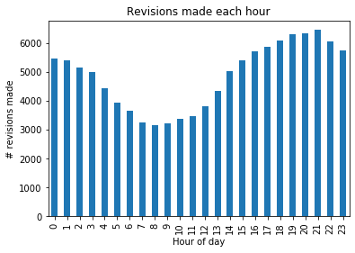

```python
revisions_by_hour.plot.bar(xlabel="Hour of day", ylabel="# revisions made", title="Revisions made each hour")
```

In the above plot of hour of day versus number of revisions, there is a clear dip in number of revisions made from the 5th to the 12th hour. The timestamps for this dataset are in UTC time, having been provided in the [ISO 8601 timestamp format](https://en.wikipedia.org/wiki/ISO_8601). Converting to eastern standard time, using [this helpful converter](https://savvytime.com/converter/utc-to-est), 5am to 12pm UTC is equivalent to 12am to 7am EST. Since a large portion of the user base of Wikipedia is from the United States, it would make sense that the least activity occurs in the middle of the night, and the most activity occurs during the daytime hours or evening.

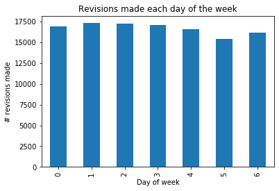

```python
revisions_by_day.plot.bar(xlabel="Day of week", ylabel="# revisions made", title="Revisions made each day of the week")
```

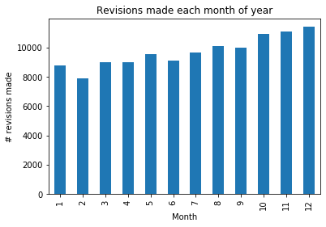

```python
revisions_by_month.plot.bar(xlabel="Month", ylabel="# revisions made", title="Revisions made each month of year")
```

For the plots of day of week and month, there aren't as clear trends. The plot for month versus number of revisions appears to have a slight upward trend, with later months showing more revisions. However, this may be caused by how the dataset was selected, as it's possible that there were simply more observations that were randomly selected for the later months.

In our dataset, we also have the count of how many words were changed in each revision. We can see if there are any trends with the revision wordcount over different units of time.

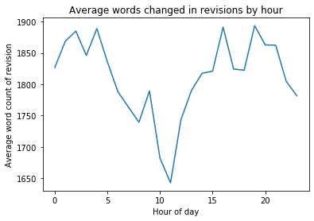

```python
df.groupby("hour")["words_revised"].mean().plot(xlabel="Hour of day", ylabel="Average word count of revision", title="Average words changed in revisions by hour")
```

It appears that, as shown on each of the above graphs, the average word count of revisions generally ranges between 1500 and 2000 words. That seems like a large amount of words being changed for the average revision! The reason why this number is so large isn't clear.

In the above plot of average words changed by hour, there is a sudden dip around the 10th hour, which corresponds to 5am EST. It should be noted that the dip is only about 300 words away from the maximum value for the averages, so in the grand scheme it may not be very significant.

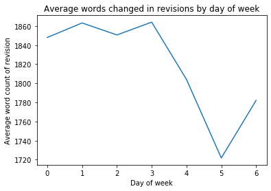

```python
df.groupby("day")["words_revised"].mean().plot(xlabel="Day of week", ylabel="Average word count of revision", title="Average words changed in revisions by day of week")
```

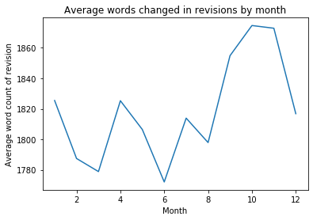

```python
df.groupby("month")["words_revised"].mean().plot(xlabel="Month", ylabel="Average word count of revision", title="Average words changed in revisions by month")
```

Above, we see a plot of average words changed for each month. There seems to be a general upward trend, but here is a lot of variation in the plot and so the observed pattern may not be very meaningful.

Moving forward, we will be focusing on the categories and external links of the dataset, so that we can start working on creating the website suggestion generator.

### Tidying categories

In the original dataset, the categories field for a single row consists of a space-separated list of categories for the article for that row. This is not tidy, as we want to be able to deal with individual categories. We need to modify the data so that each row has only one of the categories that belong to it. This will add duplication to the data, as the rest of the row will be duplicated for each of its categories, but it will make the data easier to analyze. The same will be done for the list of external links (the column named "external").

The needed operation is the "explode" operation, which does exactly what is described above for a specified column. It takes a list of values, and makes individual rows for each value in the list, duplicating the other fields in the row.

Before using the explode operation, we must first convert the item to a list structure by splitting on the spaces. Then, we simply call Pandas's explode function, specifying the column name. Documentation for the explode function can be found here: https://pandas.pydata.org/pandas-docs/stable/reference/api/pandas.DataFrame.explode.html

```python
# First, remove the extra space that is at the beginning
df["CATEGORY"] = df["CATEGORY"].str.slice(1)

# Then, split the string by spaces
df["CATEGORY"] = df["CATEGORY"].str.split(" ")
```

```python
# Some examples of the result
print(df["CATEGORY"][1])
```

```
['Social_philosophy', 'Political_theories', 'Forms_of_government', 'Anarchism', 'Political_ideology_entry_points']
```

```python
# Now, "explode" the data so that each separate category has its own row for that observation
df = df.explode('CATEGORY')
df.head()
```

|  | MAIN | EXTERNAL | MINOR | words_revised | CATEGORY | article_id | revision_id | article_title | user_id | timestamp | hour | day | month |
| --- | --- | --- | --- | --- | --- | --- | --- | --- | --- | --- | --- | --- | --- |
| 0 | Counter-culture Direct_democracy Anti-globali... | http://www.gmu.edu/departments/economics/bcap... | False | 561 | NaN | 12 | 1906836 | Anarchism | 6103 | 2003-12-08 20:47:20 | 20 | 0 | 12 |
| 1 | 467_BC Seattle,_Washington Head_of_state Curi... | http://dwardmac.pitzer.edu/Anarchist_Archives... | False | 8108 | Social_philosophy | 12 | 19019230 | Anarchism | 141644 | 2005-07-17 14:58:19 | 14 | 6 | 7 |
| 1 | 467_BC Seattle,_Washington Head_of_state Curi... | http://dwardmac.pitzer.edu/Anarchist_Archives... | False | 8108 | Political_theories | 12 | 19019230 | Anarchism | 141644 | 2005-07-17 14:58:19 | 14 | 6 | 7 |
| 1 | 467_BC Seattle,_Washington Head_of_state Curi... | http://dwardmac.pitzer.edu/Anarchist_Archives... | False | 8108 | Forms_of_government | 12 | 19019230 | Anarchism | 141644 | 2005-07-17 14:58:19 | 14 | 6 | 7 |
| 1 | 467_BC Seattle,_Washington Head_of_state Curi... | http://dwardmac.pitzer.edu/Anarchist_Archives... | False | 8108 | Anarchism | 12 | 19019230 | Anarchism | 141644 | 2005-07-17 14:58:19 | 14 | 6 | 7 |

Above, the result of the explode operation can be seen. Notice how the same article title is present for multiple rows, but the value in the category column is different for each of them. This change will make it easier for us to do analysis on the different category values, while still associating each instance of the category with the remaining features of the observation.

### Exploration of categories

Let's look at a few things about the categories. Let's see what the most frequently-used categories are, and let's graph how many articles are tagged with those categories.

```python
# Count how many unique categories there are
categories_list = df["CATEGORY"].unique()
print("# Unique categories: " + str(len(categories_list)))
```

```
# Unique categories: 85748
```

```python
# Get a count of occurrences for each category
category_counts = df["CATEGORY"].value_counts()

# Let's look at the top 10 categories
print("Number of revisions made on articles in the top categories:\n")
print(category_counts[0:10])
```

```
Number of revisions made on articles in the top categories:

Living_people                 11004
American_film_actors           1180
American_television_actors      887
English-language_films          592
American_films                  577
2000s_music_groups              528
Hollywood_Walk_of_Fame          522
Grammy_Award_winners            520
Windows_games                   513
American_musical_groups         474
Name: CATEGORY, dtype: int64
```

Let's get a count of how many articles are tagged with each category.

```python
# Count how many unique articles correspond to each category
articles_in_categories = df.groupby("CATEGORY").count()["article_id"]

# Sort the list so we can see the categories tagged in the most articles
articles_in_categories = articles_in_categories.sort_values(ascending=False)
articles_in_categories[0:20]
```

```
CATEGORY
Living_people                          11004
American_film_actors                    1180
American_television_actors               887
English-language_films                   592
American_films                           577
2000s_music_groups                       528
Hollywood_Walk_of_Fame                   522
Grammy_Award_winners                     520
Windows_games                            513
American_musical_groups                  474
American_actors                          416
American_professional_wrestlers          403
Year_of_birth_missing                    392
1981_births                              377
2000s_TV_shows_in_the_United_States      377
2000s_American_television_series         368
American_female_singers                  366
1990s_music_groups                       363
American_male_singers                    358
PlayStation_2_games                      338
Name: article_id, dtype: int64
```

### Tidying external links

We will also want to analyze the different external links that an article links to. We will do a similar operation as we did with the category column.

Rather than keeping the entire website that is linked to, we'll just focus on the domain part of the URL (e.g. www.example.com rather than www.example.com/sub/page). This will allow us to get a better picture of which websites in general are linked to, not caring about what specific page is linked to.

First, we will split the "external" column by spaces to get a list of the external links. Then, we will use the function [urlparse](https://docs.python.org/3/library/urllib.parse.html) from Python's urllib library to extract the domain from each link. Then, we will perform the explode operation to associate one domain per row, which will again duplicate the rest of the data so that we will still have access to the rest of the observation's fields.

```python
# First, remove the extra space that is at the beginning
df["EXTERNAL"] = df["EXTERNAL"].str.slice(1)

# Then, split the string by spaces
df["EXTERNAL"] = df["EXTERNAL"].str.split(" ")
```

```python
# Example list of links for the first row
print("Example links:")
print(df.iloc[0]["EXTERNAL"][0:5])
```

```
Example links:
['http://www.gmu.edu/departments/economics/bcaplan/anarfaq.htm', 'http://www.infoshop.org/faq/index.html']
```

```python
# Function that takes a list of urls and returns a list of unique domains
def get_domains (url_list):
    domains = set()
    if np.all(pd.notnull(url_list)):
        for url in url_list:
            try:
                domain = urlparse(url).netloc
            except ValueError:
                domain = np.nan
            domains.add(domain)
        #print(domains)
    return list(domains)
```

```python
# Apply the above function to each row so that the "external" column will have a list of domains
df["EXTERNAL"] = df["EXTERNAL"].apply(get_domains)

# Example result for the first row
print("Example links after it is reduced to only the domain:")
print(df.iloc[0]["EXTERNAL"][0:5])
```

```
Example links after it is reduced to only the domain:
['www.infoshop.org', 'www.gmu.edu']
```

```python
# Now, we explode the "external" column so that there is only one domain per row
df = df.explode("EXTERNAL")
df.head()
```

|  | MAIN | EXTERNAL | MINOR | words_revised | CATEGORY | article_id | revision_id | article_title | user_id | timestamp | hour | day | month |
| --- | --- | --- | --- | --- | --- | --- | --- | --- | --- | --- | --- | --- | --- |
| 0 | Counter-culture Direct_democracy Anti-globali... | www.infoshop.org | False | 561 | NaN | 12 | 1906836 | Anarchism | 6103 | 2003-12-08 20:47:20 | 20 | 0 | 12 |
| 0 | Counter-culture Direct_democracy Anti-globali... | www.gmu.edu | False | 561 | NaN | 12 | 1906836 | Anarchism | 6103 | 2003-12-08 20:47:20 | 20 | 0 | 12 |
| 1 | 467_BC Seattle,_Washington Head_of_state Curi... | road.cjb.cc | False | 8108 | Social_philosophy | 12 | 19019230 | Anarchism | 141644 | 2005-07-17 14:58:19 | 14 | 6 | 7 |
| 1 | 467_BC Seattle,_Washington Head_of_state Curi... | www.takver.com | False | 8108 | Social_philosophy | 12 | 19019230 | Anarchism | 141644 | 2005-07-17 14:58:19 | 14 | 6 | 7 |
| 1 | 467_BC Seattle,_Washington Head_of_state Curi... | struggle.ws | False | 8108 | Social_philosophy | 12 | 19019230 | Anarchism | 141644 | 2005-07-17 14:58:19 | 14 | 6 | 7 |

Great! Now we have one external link in each row. The same effect as what happened with the category processing can be seen above. The same article title (and associated fields) is seen, but with different external links in the "external" column.

Let's do some exploration of the external domains that are linked to.

```python
# Let's get a count of how many unique domains are linked to
print("# Unique domains linked to: " + str(len(df["EXTERNAL"].unique())))
```

```
# Unique domains linked to: 230324
```

```python
# Get a count of the occurences of each domain
domain_counts = df["EXTERNAL"].value_counts()

# We can look at the most linked to domains
print("Domains and the number of times they are linked to by articles:")
print(domain_counts[0:10])
```

```
Domains and the number of times they are linked to by articles:
news.bbc.co.uk            47445
www.imdb.com              22507
www.nytimes.com           19741
www.cnn.com               17677
www.washingtonpost.com    16412
www.geocities.com         16252
www.bbc.co.uk             16061
www.time.com              14516
www.usatoday.com          14433
www.youtube.com           14384
Name: EXTERNAL, dtype: int64
```

Now that we've processed the categories and external links columns so that each row contains only one category and only one external link, we are done with the data processing and data exploration stage.

## Learning on the data

### Preparing the links and categories for clustering

From here on, we will be focusing on making our website suggestion generator. Given a category for an article someone is working on, we should be able to generate a suggestion of a website to do research on.

One important part in accomplishing this task is the use of a clustering algorithm. A clustering algorithm will help us to form groups of similar categories. It is important to have groups of categories so that our website suggestion generator can provide useful suggestions. For instance, say that we are trying to suggest websites related to a particular category, but we only know of a few websites that are associated with that category. However, if we know what other categories are related to this category (because they are in the same category group), then we can suggest the websites associated with the similar categories.

We will be using the [kmeans algorithm](https://en.wikipedia.org/wiki/K-means_clustering) for clustering the categories. The kmeans algorithm groups together categories based on their similarity. In our case, similarity means that the categories have similar websites that they link to.

To this end, for each category, we will want a list of what websites articles in the category link to, and the frequency of how often each website is linked to. We will format this information in a data structure which we will then pass into the kmeans function of the sklearn library. The output of the kmeans function will tell us the groupings of categories that were generated.

First, we'll find the frequency of each website linked in each category.

```python
# For each category, get a count of each domain being linked to
link_counts_by_cat = df[["CATEGORY", "EXTERNAL"]].value_counts()
link_counts_by_cat.head()
```

```
CATEGORY       EXTERNAL
Living_people  news.bbc.co.uk     1265
               www.imdb.com        758
               www.myspace.com     603
               www.youtube.com     524
               www.nytimes.com     495
dtype: int64
```

Now, we want a table where each row represents one category, each column represents one website domain, and the value at each cell represents the number of times that the domain shows up in articles of that category.

To do so, we can use the Pandas unstack operation on the dataframe of categories and domains that we just created, which will form exactly the structure we want. ([Here are examples of the unstack() function](https://pandas.pydata.org/pandas-docs/stable/reference/api/pandas.DataFrame.unstack.html))

```python
# Create a table showing the number of articles each category has for each domain
link_counts_by_cat[0:5].unstack().fillna(0)
```

| EXTERNAL CATEGORY | news.bbc.co.uk | www.imdb.com | www.myspace.com | www.youtube.com | www.nytimes.com |
| --- | --- | --- | --- | --- | --- |
| Living_people | 1265 | 758 | 603 | 524 | 495 |

However, there's a problem with this. In order to represent all of the domains and categories that we have, this would form so large of a dataframe that Python will not be able to store it in memory.

To work around this, we can take advantage of one fact: out of all the possible domains in the dataset, any given category will only consist of some of them. In other words, for one category, a select portion of the domains will have values, while the remaining ones will all be zeroes.

This means that we can represent this data much more efficiently in a sparse matrix, which is a matrix where most values are zero. In a sparse matrix, only the non-zero values need to be stored in memory along with their row and column positions, while the remaining positions are implicitly zero. We will then be able to pass this sparse matrix into the kmeans function.

Fortunately, the scipy library has a data structure meant especially for this: the csr_matrix (compressed sparse row matrix). Read here to find more about this data structure: https://docs.scipy.org/doc/scipy/reference/generated/scipy.sparse.csr_matrix.html

To initialize a csr_matrix, we need to pass in three arrays: one array containing all of the values that we want to store, one array containing all of the row indicies for each value, and one array containing all of the column indicies for each value. See the link above for an example of what such input and output might look like.

```python
# First, we create a list of all of the unique domains and categories in our data
all_domains = list(df["EXTERNAL"].unique())
all_categories = list(df["CATEGORY"].unique())
```

```python
# Next, we create two dictionaries where the key is either the category or domain name, and
# the value is the index of that category or domain in the overall list.
# We do this so that we can access the correct row or column index for a category or domain in constant time,
# so we can efficiently build our sparse matrix.
all_domain_indicies = { all_domains[x] : x for x in range(len(all_domains)) }
all_category_indicies = { all_categories[x] : x for x in range(len(all_categories)) }
print(list(all_domain_indicies.items())[0:5])
print(list(all_category_indicies.items())[0:5])
```

```
[('www.infoshop.org', 0), ('www.gmu.edu', 1), ('road.cjb.cc', 2), ('www.takver.com', 3), ('struggle.ws', 4)]
[(nan, 0), ('Social_philosophy', 1), ('Political_theories', 2), ('Forms_of_government', 3), ('Anarchism', 4)]
```

```python
# Now, we contruct the arrays needed to build the sparse matrix.

# The data array holds all of the domain counts from our dataset.
data = link_counts_by_cat.values
data
```

```
array([1265,  758,  603, ...,    1,    1,    1], dtype=int64)
```

```python
# The rows array will contain the corresponding category index value for each data value above.
# It is formed by taking the index of the dataframe, extracting the category name, and converting
# the name to its index through the dictionary we created above.
rows = link_counts_by_cat.index.to_series().apply( lambda x : all_category_indicies[x[0]]).values
rows
```

```
array([  172,   172,   172, ..., 40211, 40211, 82079], dtype=int64)
```

```python
# The columns array will contain the corresponding domain index value for each data value.
# It is formed by extracting the domain name from the dataframe, and converting it to its correct index.
cols = link_counts_by_cat.index.to_series().apply( lambda x : all_domain_indicies[x[1]]).values
cols
```

```
array([  130,   484,  3561, ..., 14310, 71380,   130], dtype=int64)
```

```python
# Finally, we form the sparse matrix. We will be able to pass this data structure into the kmeans function for clustering.
sparse_matrix = csr_matrix((data, (rows, cols)))
```

Our sparse matrix is now formed, and it all fits in memory (since we aren't storing lots of extra zeroes now)! We can now perform clustering on the data.

### K-Means clustering to group together similar categories

We will now perform k-means clustering to create groupings of categories based on the similarity of the categories, where similarity is based on the particular domains that articles in the categories link to.

One consideration is our value of "k", which represents the number of groupings (called clusters) that the algorithm will generate. There's not a particular amount of groupings that we are looking for, so let's use a value of k=20, which seems reasonable and won't take very much computational time.

```python
num_clusters = 20
kmeans_result = KMeans(n_clusters=num_clusters).fit(sparse_matrix)
```

And with that, we've performed kmeans! Let's take a look at what the results are.

```python
# Get the number of categories that were placed in each cluster
print("Cluster ID, and # categories in this cluster")
pd.Series(kmeans_result.labels_).value_counts()
```

```
Cluster ID, and # categories in this cluster
```

```
16    82272
14     2814
8       194
7       179
11       81
13       31
18       31
0        29
15       28
10       21
2        18
12       16
6        11
19        7
9         4
5         3
3         3
17        3
4         2
1         1
dtype: int64
```

Above is the distribution of categories in each cluster. The value on the left is the cluster ID, and the value on the right is the number of categories in that cluster.

It appears that just a few of the clusters contain a majority of the categories, while the rest of the clusters consist of relatively fewer categories. This definitely isn't a good thing for our goal of a website suggestion generator - if so many categories are clumped together, we won't have much specificity in suggesting a website. This is something we will keep in mind moving forward, and we may try to find a way to improve this distribution.

For now, we will work with this result, and continue building the infrastructure for the website suggestion generator.

First, let's visualize a little bit better what the groupings of categories look like.

```python
# Retrive the list of all labels. Each element in this array represents the cluster ID
# that each category belongs to.
kmeans_labels = kmeans_result.labels_
kmeans_labels
```

```
array([16, 14, 14, ..., 16, 16, 16])
```

The information that we have from the kmeans algorithm is the ID of the cluster that each category belongs to. Let's translate this list of IDs into a more human-readable format. For each cluster, we want to have a list of all the categories in that cluster.

```python
# We want a list of the clusters. So, a list, where each value is a set, and each set
# represents one cluster, and the members of the set are the categories in that cluster.

clusters_dict = defaultdict(set)
for i in range(0, len(all_categories)):
    cluster_id = kmeans_labels[i]
    category_name = all_categories[i]

    clusters_dict[cluster_id].add(category_name)


# Convert the dictionary to a list of sets, where each set represents the categories in one cluster
clusters_list = list(clusters_dict.values())
```

```python
# Printing some examples
print("The first five categories in each cluster: \n")
for cluster in clusters_list:
    print(list(cluster)[0:5])
```

```
The first five categories in each cluster:

[nan, 'Religious_demographics', 'Friends_episodes', 'School_districts_in_Georgia_(U.S._state)', 'Motor_skills']
['July_2005_London_bombings', 'Sirius_Satellite_Radio_channels', 'Georgia_State_Senators', 'Former_Catholics', 'Best_Supporting_Actor_Golden_Globe_Nominee_(television)']
['Harvard_University_alumni', 'Democratic_Party_(United_States)_presidential_nominees', 'Cold_War_leaders', 'Irish-American_politicians', 'Time_magazine_Persons_of_the_Year']
['Bonesmen', '1946_births', 'People_from_Texas', 'Governors_of_Texas', 'Current_national_leaders']
['Baptists_from_the_United_States', 'Battles_of_Israel', 'American_entrepreneurs', '2007_in_Iraq', 'Politics_of_Iran']
['Drama_films', 'Fantasy_films', 'New_Line_Cinema_films', 'Battle_of_Thermopylae', 'Post-apocalyptic_science_fiction_films']
['G15_nations', 'English-speaking_countries', 'Bicontinental_countries', 'Seafaring_nations', 'European_Union_member_states']
['High_school_dropouts', 'Canadian_female_singers', 'American_soap_opera_actors', 'Cause_of_death_disputed', 'Breast_cancer_activists']
['Living_people']
['2006_computer_and_video_games', 'Mac_OS_X_games', 'Video_games_developed_in_Japan', 'Nintendo_DS_games', 'Games_for_Windows_certified_games']
['American_film_actors', 'American_television_actors', 'Hollywood_Walk_of_Fame']
['Scottish-Americans', 'Irish-Americans', 'American_adoptive_parents', '2004_deaths', 'Knights_Grand_Cross_of_the_Order_of_the_Bath']
['African-American_actors', 'American_rock_singers', "Kids'_Choice_Awards_winners", 'Juno_Award_winners', '2006_albums']
['Aviators', 'Bush_family', 'Harvard_alumni', 'Methodists', 'Intelligent_design_advocates']
['2000s_TV_shows_in_the_United_States', 'Fox_network_shows', 'American_comedians', '1990s_American_television_series', 'CBS_network_shows']
['Grammy_Award_winners', 'American_female_singers', 'American_pop_singers']
['FA_Premier_League_clubs', 'England_under-21_international_footballers', 'English_footballers', 'England_international_footballers', 'English_football_clubs']
['English-language_films', 'American_films']
['2006_films', '2007_films', 'Sequel_films', 'Films_shot_in_Super_35']
['American_musical_groups', '2000s_music_groups', '1990s_music_groups']
```

By visual inspection, it appears that the clustering is going well! As seen above, similar categories have been grouped together. For instance, categories related to video games are together, and categories about music groups are together. It seems that the list of domains has the potential to be a sufficient metric for determining related categories.

Next, we want to use these clusters to be able to suggest a website to research on, given the category of an article someone is working on. To do so, we will create a list of websites that are associated with each cluster, based on the links we found for each category in that cluster. Then, when the user asks for website suggestions for a particular category, we can look up which cluster the category belongs to, and return the most common websites linked to for that cluster.

```python
# Previously in the code, we created a data structure that associates a list
# of links (and their counts) with a category name.
# We will use this data structure to aggregate the links for all categories in a cluster

# Here is an example of getting the links associated with a particular category.
list(link_counts_by_cat['American_World_War_II_veterans'].items())[0:8]
```

```
[('vvl.lib.msu.edu', 33),
 ('www.whitehouse.gov', 33),
 ('www.cnn.com', 23),
 ('www.americanrhetoric.com', 22),
 ('www.pbs.org', 19),
 ('www.doctorzebra.com', 17),
 ('www.washingtonpost.com', 17),
 ('www.archives.gov', 17)]
```

```python
# For each cluster, we want to aggregate the links for all categories in that cluster.
# The result should be a dictionary where the key is the cluster (as a set of category names),
# and the value is a dictionary of domain names with their frequencies.

cluster_links = defaultdict(lambda: defaultdict(int))
for cluster in clusters_list: # For each cluster
    cluster_set = frozenset(cluster) # create a frozenset so that we can use the set as a key in the dictionary
    for category in cluster: # For each category in this cluster
        if category in link_counts_by_cat: # If this is a category we have links for
            links = link_counts_by_cat[category] # Get all the links associated with this category

            for link, count in links.items(): # For each link
                if count > 0:
                    cluster_links[cluster_set][link] += count  # Add it to this cluster's list of links
```

```python
# Showing an example of the result from the above operation
cluster_with_links = list(cluster_links.items())[5]
print("Example of the links associated with one particular cluster:\n")
print("Cluster: \n" + str(list(set(cluster_with_links[0]))[0:10]) + "\n")
print("Subset of links for this cluster: \n" + str(list(cluster_with_links[1].items())[0:10]))
```

```
Example of the links associated with one particular cluster:

Cluster:
['Computer-animated_films', 'British_films', 'Drama_films', 'Independent_films', 'Fantasy_films', 'Spider-Man_films', 'Coming-of-age_films', 'New_Line_Cinema_films', 'BAFTA_winners_(people)', 'Battle_of_Thermopylae']

Subset of links for this cluster:
[('www.imdb.com', 1180), ('www.rottentomatoes.com', 968), ('rogerebert.suntimes.com', 659), ('www.boxofficemojo.com', 772), ('www.metacritic.com', 415), ('imdb.com', 253), ('film.guardian.co.uk', 277), ('www.ew.com', 414), ('www.cnn.com', 226), ('www.nytimes.com', 338)]
```

Above, we have created a data structure that contains each cluster paired with the list of links associated with all categories in that cluster.

Now we can write a function that gives suggested links, given a category name.

```python
def get_suggested_links(category_name):
    # First, identify which cluster this category belongs to.
    for cluster, links in cluster_links.items():
        if category_name in cluster: # We found the cluster for this category
            # return the list of links for this cluster
            return sorted(links.items(), key=lambda x : x[1], reverse=True)
```

```python
get_suggested_links("American_films")[0:10]
```

```
[('www.rottentomatoes.com', 307),
 ('www.imdb.com', 306),
 ('www.boxofficemojo.com', 254),
 ('rogerebert.suntimes.com', 179),
 ('www.variety.com', 156),
 ('www.metacritic.com', 149),
 ('www.ew.com', 133),
 ('www.comingsoon.net', 122),
 ('www.usatoday.com', 116),
 ('www.hollywoodreporter.com', 103)]
```

```python
get_suggested_links("Internet_memes")[0:10]
```

```
[('news.bbc.co.uk', 2867),
 ('www.cnn.com', 2537),
 ('www.washingtonpost.com', 2514),
 ('www.nytimes.com', 2406),
 ('www.pbs.org', 1743),
 ('www.msnbc.msn.com', 1667),
 ('www.whitehouse.gov', 1629),
 ('www.guardian.co.uk', 1453),
 ('www.time.com', 1445),
 ('www.foxnews.com', 1354)]
```

```python
get_suggested_links("Governors_of_Texas")[0:10]
```

```
[('news.bbc.co.uk', 429),
 ('www.cnn.com', 396),
 ('www.washingtonpost.com', 366),
 ('www.nytimes.com', 359),
 ('www.whitehouse.gov', 335),
 ('www.cbsnews.com', 324),
 ('www.usatoday.com', 308),
 ('www.yale.edu', 302),
 ('archives.cnn.com', 297),
 ('www.cbc.ca', 281)]
```

Fantastic! We now have the infrastructure for the website suggestion generator.

### Room for improvement

The above results look promising, however there are a few potential areas of improvement.

First of all, when asking for suggested links for a particular category, there are some websites that show up over and over again for many of the categories. For example, news.bbc.co.uk or nytimes.com show up under many categories with high frequencies. Although these are likely good sources for research for a particular category, they aren't the type of specific website suggestions that would make this model useful.

Secondly, the distribution of categories in the above clusters is heavily skewed, with only a few clusters containing a majority of the categories. A more accurate system should have clusters that more evenly divide the categories. This would mean that each cluster is specialized for a particular set of categories all having something in common, and thus providing a set of websites that would be useful under that umbrella of topics.

There's a possibility that solving the first issue might solve the second issue. One possibility for why the clusters are coming out so skewed could be that since many categories link to the most frequent domains, those categories are being grouped together based on that similarity. We instead want the categories to be grouped based on the websites that are more unique to those categories.

### Clustering with inverse document frequency

Thus, we turn to the concept of inverse document frequency (IDF). This is a concept normally seen in contexts related to natural language processing (NLP). In that context, inverse document frequency is used to apply a lesser weight to words that show up in more documents. In other words, it puts more weight on the words that are more unique to each document and don't show up as much elsewhere, so that the key features of the document can stand out when performing NLP tasks. You can read more about inverse document frequency here: https://nlp.stanford.edu/IR-book/html/htmledition/inverse-document-frequency-1.html

In the context of our categories and websites, we would want to apply the concept of inverse document frequency to the websites for each category. To calculate the IDF for each website, we take the number of total categories and divide this number by the number of categories that link to this website, and then take the log of the whole expression. Then, for the website described for each category, we would multiply the IDF value for the particular frequency of this website in the category, to still incorporate the importance of this website for this particular category. In NLP, the equivalent concept is [TF-IDF (term frequency, inverse document frequency)](https://towardsdatascience.com/introduction-to-nlp-part-3-tf-idf-explained-cedb1fc1f7dc)

$$ \text{weight value for website w in category c} = freq_{w,c} \cdot log{\frac{\text{# total categories}}{\text{# categories that link to w}}} $$

First, we will construct a dictionary where the key is the domain name, and the value is the number of categories that link to the domain.

```python
# Group our original data by domain name, so all rows for the same domain name are consecutive
d = df[["EXTERNAL", "CATEGORY"]].set_index("EXTERNAL").groupby("EXTERNAL")
d.head()
```

| EXTERNAL | CATEGORY |
| --- | --- |
| www.infoshop.org | NaN |
| www.gmu.edu | NaN |
| road.cjb.cc | Social_philosophy |
| www.takver.com | Social_philosophy |
| struggle.ws | Social_philosophy |
| ... | ... |
| www.inr.ru | Russian_Academy_of_Sciences |
| www.inr.ru | Nuclear_and_atomic_physics_stubs |
| www.inr.ru | Universities_and_institutes_established_in_the... |
| haggin.org | American_racehorse_owners_and_breeders |
| haggin.org | Horse_farms |

865022 rows × 1 columns

```python
# Next, count the number of unique categories that are associated with each domain
d1 = d.nunique()
d1
```

| EXTERNAL | CATEGORY |
| --- | --- |
|  | 34 |
| " | 4 |
| ", | 4 |
| --Ladi--.bebo.com | 4 |
| -_-spoken-_-ARTIST.com-_-.4rtist.com | 3 |
| ... | ... |
| 国际域名.net | 1 |
| 孟子.com | 1 |
| 影视.tv | 1 |
| 言語.net | 1 |
| 항공.com | 1 |

230323 rows × 1 columns

```python
# Convert the above dataframe into a dictionary so that we can search for any domain we want
num_categories_with_domains = d1.to_dict()['CATEGORY']
```

```python
# Here is an example of checking for a specific domain, how many unique categories link to it
print("Example: # categories that link to the domain 'www.washingtonpost.com':")
print(num_categories_with_domains["www.washingtonpost.com"])
```

```
Example: # categories that link to the domain 'www.washingtonpost.com':
5550
```

```python
# The domains linked to by the most categories
sorted_domains = sorted(list(num_categories_with_domains.items()), key=lambda x : x[1], reverse=True)[0:10]
sorted_domains
```

```
[('news.bbc.co.uk', 14748),
 ('www.geocities.com', 8084),
 ('www.imdb.com', 7762),
 ('www.nytimes.com', 7054),
 ('www.bbc.co.uk', 6914),
 ('www.youtube.com', 6423),
 ('www.guardian.co.uk', 5699),
 ('www.cnn.com', 5681),
 ('www.time.com', 5678),
 ('www.washingtonpost.com', 5550)]
```

```python
sorted_domains = [x[0] for x in sorted_domains]
sorted_domains
```

```
['news.bbc.co.uk',
 'www.geocities.com',
 'www.imdb.com',
 'www.nytimes.com',
 'www.bbc.co.uk',
 'www.youtube.com',
 'www.guardian.co.uk',
 'www.cnn.com',
 'www.time.com',
 'www.washingtonpost.com']
```

Next, we will update the value for each domain in each category with the TF-IDF.

```python
# Now, we want to adjust the values for the domain in each category, with the tf-idf
df_with_idf = link_counts_by_cat.copy()
df_with_idf
```

```
CATEGORY                 EXTERNAL
Living_people            news.bbc.co.uk      1265
                         www.imdb.com         758
                         www.myspace.com      603
                         www.youtube.com      524
                         www.nytimes.com      495
                                             ...
Magnet_schools           www.acorn.org          1
                         www.alternet.org       1
                         www.bergen.org         1
                         www.bosmun.org         1
"Politics_of"_templates  news.bbc.co.uk         1
Length: 2596258, dtype: int64
```

```python
num_categories = len(all_categories)
i = 0
for index, row in df_with_idf.iteritems(): # For each domain in a particular category
    #i += 1; print(str(i) + " / " + str(len(df_with_idf)))
    domain = index[1]  # Get the domain name
    idf = np.log(num_categories / num_categories_with_domains[domain]) # Calculate the inverse document frequency
    df_with_idf[index] = row * idf  # Set the new value to be the previous value times the idf (so it's the tf-idf)
```

```python
# Re-form the sparse matrix (the same operations as we did for the previous clustering operation)
data = df_with_idf.values
rows = df_with_idf.index.to_series().apply( lambda x : all_category_indicies[x[0]]).values
cols = df_with_idf.index.to_series().apply( lambda x : all_domain_indicies[x[1]]).values
sparse_matrix = csr_matrix((data, (rows, cols)))
```

```python
# Perform clustering again
num_clusters = 20
kmeans_result_idf = KMeans(n_clusters=num_clusters).fit(sparse_matrix)
```

```python
kmeans_labels_idf = kmeans_result_idf.labels_
pd.Series(kmeans_labels_idf).value_counts()
```

```
1     84566
14      783
16      103
9        60
0        40
3        35
12       31
10       27
8        19
15       16
5        16
18       14
13       12
7         6
19        6
11        4
4         4
17        3
6         2
2         1
dtype: int64
```

```python
# We repeat the same operations as before, to create a list of the categories in each cluster.

# We want a list of the clusters. So, a list, where each value is a set, and each set
# represents one cluster, and the members of the set are the categories in that cluster.
clusters_dict = defaultdict(set)
for i in range(0, len(kmeans_labels_idf)):
    cluster_id = kmeans_labels_idf[i]
    category_name = all_categories[i]

    clusters_dict[cluster_id].add(category_name)


# Convert the dictionary to a list of sets, where each set represents the categories in one cluster
clusters_list = [x[1] for x in sorted(list(clusters_dict.items()), key=lambda x:x[0])]


# Printing some examples
print("The first five categories in each cluster: \n")
for cluster in clusters_list:
    print(list(cluster)[0:5])
```

```
The first five categories in each cluster:

['G15_nations', 'English-speaking_countries', 'Bicontinental_countries', 'Seafaring_nations', 'European_Union_member_states']
[nan, 'Religious_demographics', 'Friends_episodes', 'School_districts_in_Georgia_(U.S._state)', 'Motor_skills']
['Living_people']
['2006_computer_and_video_games', 'Wii', 'Wii-only_games', 'Mac_OS_X_games', 'Video_games_developed_in_Japan']
['Time_magazine_Persons_of_the_Year', 'Presidents_of_the_United_States', 'Presidential_Medal_of_Freedom_recipients', 'Republican_Party_(United_States)_presidential_nominees']
['Yale_University_alumni', 'Texas_Republicans', 'Children_of_Presidents_of_the_United_States', 'Long-distance_runners', 'American_conservatives']
['Windows_games', 'Xbox_360_games']
['American_actor-singers', 'American_television_actors', 'American_pop_singers', 'American_film_actors', 'Grammy_Award_winners']
['FA_Premier_League_clubs', 'England_under-21_international_footballers', 'English_footballers', 'England_international_footballers', 'Preston_North_End_F.C._players']
['Elks', 'History_of_the_United_States_(1918–1945)', 'Members_of_the_United_States_House_of_Representatives_from_Massachusetts', 'U.S._Democratic_Party_vice_presidential_nominees', 'American_military_personnel_of_World_War_II']
['2007_in_Iraq', '2005_in_Iraq', 'Religion_and_violence', 'Counter-terrorism', 'United_States-Iraqi_relations']
['FIFA_World_Cup_2006_players', 'UEFA_Euro_2004_players', 'Premier_League_players', 'La_Liga_footballers']
['Scottish-Americans', 'Irish-Americans', 'American_adoptive_parents', 'Cold_War_leaders', '2004_deaths']
['Bush_family', 'Bonesmen', 'Methodists', '1946_births', 'People_from_Texas']
['Battles_of_Israel', 'Georgia_State_Senators', 'Former_Catholics', 'Best_Supporting_Actor_Golden_Globe_Nominee_(television)', 'Ivy_League']
['Viennese_composers', 'People_buried_in_unmarked_graves', 'Austrian_Freemasons', 'Romantic_composers', 'Classical_era_composers']
['High_school_dropouts', 'Falsettos', 'Worst_Actress_Razzie', '2007_singles', '1960s_music_groups']
['American_musical_groups', '2000s_music_groups', '1990s_music_groups']
['Aviators', 'Harvard_alumni', 'Intelligent_design_advocates', 'Worst_Actor_Razzie', 'Plame_affair']
['English-language_films', '2007_films', 'Films_shot_in_Super_35', 'American_films', 'Sequel_films']
```

Unfortunately, it doesn't seem like the implementation of inverse document frequency caused a large difference in the result. The distribution of categories in the clusters is still heavily skewed, and in fact more so than with our original attempt. Further investigation could reveal why this is the case, and what could be done to make a more even split of clusters. Perhaps the links in the categories simply aren't a good enough metric of the categories to be able to come up with meaningful groupings. Perhaps many categories don't have enough external links to be able to create meaningful associations. Or, perhaps a different curation of the data or a different algorithm could better formulate these categories in order to give meaningful suggestions for the broadest selection of categories.

For now, we can still do some analysis of some trends with the smaller category clusters that are evidently well-grouped.

### Distribution of revisions, grouped by category cluster

It may be interesting to see if there are any trends in the number of revisions or the word count of revisions when we group by cluster. i.e. does a certain cluster of categories show a unique pattern in the distribution of revisions?

We need to add a column to our original dataset, describing which category cluster the row belongs to. (We will be using the results from our first attempt at clustering, since the distribution of categories across clusters seemed more even.)

```python
category_groups_df = pd.DataFrame()
category_groups_df["cat"] = pd.Series(all_categories) # Each row represents one category
category_groups_df["cat_group"] = pd.Series(kmeans_labels) # This column holds the cluster ID for the category
category_groups_df = category_groups_df.set_index("cat") # Set the index so we can access the ID, given the category

print("DataFrame associating group ID with category name:")
category_groups_df.head()
```

```
DataFrame associating group ID with category name:
```

| cat | cat_group |
| --- | --- |
| NaN | 16 |
| Social_philosophy | 14 |
| Political_theories | 14 |
| Forms_of_government | 16 |
| Anarchism | 14 |

```python
# A function that takes in a category name, and returns the ID of the cluster it belongs to
def get_cluster_id(category_name):
    if category_name in category_groups_df.index:
        return category_groups_df.loc[category_name]["cat_group"]
    return np.nan
```

```python
# An example of getting the cluster ID
get_cluster_id("American_film_actors")
```

```
17
```

```python
# Add a column to the original dataframe for the cluster_id that the category for each row belongs to
df["cluster_id"] = df["CATEGORY"].apply(lambda category_name : get_cluster_id(category_name))
```

```python
df.head()
```

|  | MAIN | EXTERNAL | MINOR | words_revised | CATEGORY | article_id | revision_id | article_title | user_id | timestamp | hour | day | month | cluster_id |
| --- | --- | --- | --- | --- | --- | --- | --- | --- | --- | --- | --- | --- | --- | --- |
| 0 | Counter-culture Direct_democracy Anti-globali... | www.infoshop.org | False | 561 | NaN | 12 | 1906836 | Anarchism | 6103 | 2003-12-08 20:47:20 | 20 | 0 | 12 | 16 |
| 0 | Counter-culture Direct_democracy Anti-globali... | www.gmu.edu | False | 561 | NaN | 12 | 1906836 | Anarchism | 6103 | 2003-12-08 20:47:20 | 20 | 0 | 12 | 16 |
| 1 | 467_BC Seattle,_Washington Head_of_state Curi... | road.cjb.cc | False | 8108 | Social_philosophy | 12 | 19019230 | Anarchism | 141644 | 2005-07-17 14:58:19 | 14 | 6 | 7 | 14 |
| 1 | 467_BC Seattle,_Washington Head_of_state Curi... | www.takver.com | False | 8108 | Social_philosophy | 12 | 19019230 | Anarchism | 141644 | 2005-07-17 14:58:19 | 14 | 6 | 7 | 14 |
| 1 | 467_BC Seattle,_Washington Head_of_state Curi... | struggle.ws | False | 8108 | Social_philosophy | 12 | 19019230 | Anarchism | 141644 | 2005-07-17 14:58:19 | 14 | 6 | 7 | 14 |

Now that we've added the cluster ID to the original dataframe, we can plot some features.

To start, for each cluster, we want a line that shows the number of revisions over time.

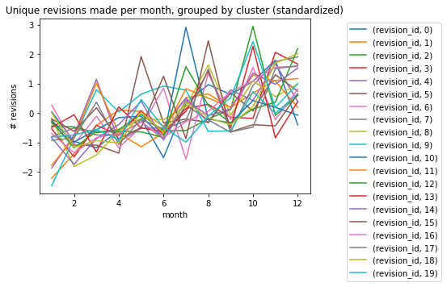

```python
df_month = df.groupby(["month", "cluster_id"])[["revision_id"]].count().unstack()

# Normalize the data so that we can compare between clusters with different number of revisions within them
df_month = df_month.apply(lambda x : (x - x.mean()) / x.std())
df_month.plot(title="Unique revisions made per month, grouped by cluster (standardized)", ylabel="# revisions").legend(bbox_to_anchor=(1.5,1))
```

In the above plot of revisions per month, all of the clusters share an upward trend. Some of the clusters spike above the rest at certain points, but it seems to be just a result of variation in the dataset.

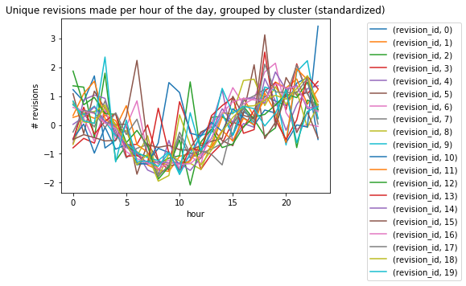

```python
df_hour = df.groupby(["hour", "cluster_id"])[["revision_id"]].count().unstack()

# Normalize the data so that we can compare between clusters with different number of revisions within them
df_hour = df_hour.apply(lambda x : (x - x.mean()) / x.std())
df_hour.plot(title="Unique revisions made per hour of the day, grouped by cluster (standardized)", ylabel="# revisions").legend(bbox_to_anchor=(1.5,1))
```

```python
clusters_list[10]
```

```
{'2003_Iraq_conflict',
 '2003_in_Iraq',
 '2004_in_Iraq',
 '2005_in_Iraq',
 '2006_in_Iraq',
 '2007_in_Iraq',
 '21st_century_eras',
 'Al-Qaeda',
 'Anti-terrorism_policy_of_the_United_States',
 'Conflicts_in_2003',
 'Conflicts_in_2004',
 'Conflicts_in_2005',
 'Conflicts_in_2006',
 'Conflicts_in_2007',
 'Counter-terrorism',
 'George_W._Bush_administration_controversies',
 'History_of_Iraq',
 'Iraqi_insurgency',
 'Islamist_terrorism',
 'Modern_history',
 'Occupation_of_Iraq',
 'Politics_of_Iraq',
 'Religion_and_violence',
 'Terrorism',
 'United_States-Iraqi_relations',
 'War_on_Terrorism',
 'Wars_involving_the_United_States'}
```

The above cluster does seem cohesive in that it groups together evidently similar categories. Perhaps there is some reason why articles in these categories may receive more revisions around the 8th hour (UTC). However, it may also be due to chance variation in the data.

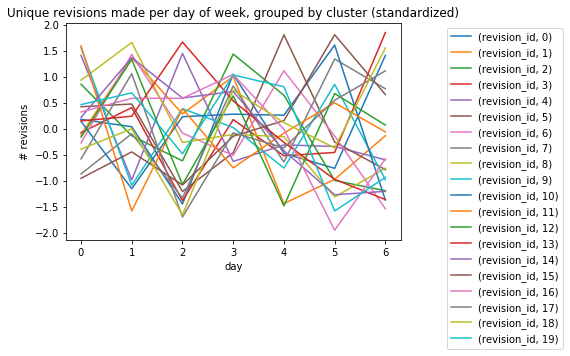

```python
df_day = df.groupby(["day", "cluster_id"])[["revision_id"]].count().unstack()

# Normalize the data so that we can compare between clusters with different number of revisions within them
df_day = df_day.apply(lambda x : (x - x.mean()) / x.std())
df_day.plot(title="Unique revisions made per day of week, grouped by cluster (standardized)", ylabel="# revisions").legend(bbox_to_anchor=(1.5,1))
```

Above is the number of revisions by the day of week, and there aren't any clear trends. There is a lot of variation among all of the clusters.

Next, let's look at the average number of words that were changed per revision, along the same time units.

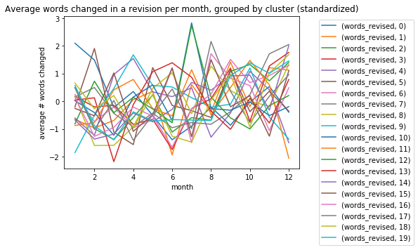

```python
df_month = df.groupby(["month", "cluster_id"])[["words_revised"]].mean().unstack()

# Normalize the data so that we can compare between clusters with different number of revisions within them
df_month = df_month.apply(lambda x : (x - x.mean()) / x.std())
df_month.plot(title="Average words changed in a revision per month, grouped by cluster (standardized)", ylabel="average # words changed").legend(bbox_to_anchor=(1.5,1))
```

```python
clusters_list[12]
```

```
{'1911_births',
 '2004_deaths',
 'American_B-movie_actors',
 'American_Presbyterians',
 'American_actor-politicians',
 'American_adoptive_parents',
 'American_anti-communists',
 'American_ranchers',
 'California_politicians',
 'Chicago_Cubs',
 'Cold_War_leaders',
 'Congressional_Gold_Medal_recipients',
 'Conservatives',
 'Deaths_by_pneumonia',
 "Deaths_from_Alzheimer's_disease",
 'English_Americans',
 'Governors_of_California',
 'Hollywood_Walk_of_Fame',
 'Iran-Contra_Affair',
 'Irish-American_politicians',
 'Irish-Americans',
 'Knights_Grand_Cross_of_the_Order_of_the_Bath',
 'People_from_California',
 'People_from_Lee_County,_Illinois',
 'People_from_Los_Angeles',
 'People_from_Whiteside_County,_Illinois',
 'Reagan_family',
 'Ronald_Reagan',
 'Scots-Irish_Americans',
 'Scottish-Americans',
 'Shooting_victims'}
```

This cluster seems to consist of categories related to certain classes of people. There's no obvious explanation for why there might be more words changed per revision for these categories, but it's interesting to see what the cluster is made up of.

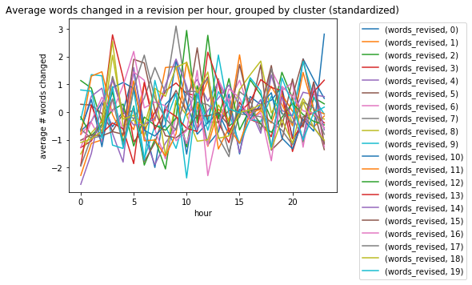

```python
df_hour = df.groupby(["hour", "cluster_id"])[["words_revised"]].mean().unstack()

# Normalize the data so that we can compare between clusters with different number of revisions within them
df_hour = df_hour.apply(lambda x : (x - x.mean()) / x.std())
df_hour.plot(title="Average words changed in a revision per hour, grouped by cluster (standardized)", ylabel="average # words changed").legend(bbox_to_anchor=(1.5,1))
```

Above is the average words changed by hour of the day, and there aren't any clear trends or outliers.

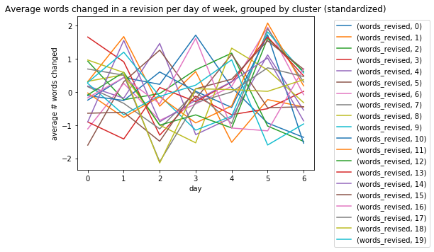

```python
df_day = df.groupby(["day", "cluster_id"])[["words_revised"]].mean().unstack()

# Normalize the data so that we can compare between clusters with different number of revisions within them
df_day = df_day.apply(lambda x : (x - x.mean()) / x.std())
df_day.plot(title="Average words changed in a revision per day of week, grouped by cluster (standardized)", ylabel="average # words changed").legend(bbox_to_anchor=(1.5,1))
```

```python
clusters_list[18]
```

```
{'American_aviators',
 'Aviators',
 'Born-again_Christians',
 'CEOs_of_America',
 'Delta_Kappa_Epsilon_brothers',
 'Entrepreneurs',
 'George_H.W._Bush',
 'Harvard_alumni',
 'Intelligent_design_advocates',
 'People_convicted_of_drunk_driving',
 'Plame_affair',
 'Presidents_of_the_U.S.',
 'Worst_Actor_Razzie',
 'Yale_alumni'}
```

This cluster isn't as cohesive as the other ones we looked at. This is an example of where the clustering definitely has room for improvement.

# Conclusion

As we've noted, the result of the kmeans clustering is far from perfect. However, we've demonstrated that there is potential in grouping together categories based on external links, and generating insights from those groupings. Additionally, we've prototyped a system for generating website suggestions for a certain category. This is the start of what could be a useful tool for someone who is contributing to a Wikipedia article and looking for relevant sources of information.

Further investigation would be needed to determine how to improve the result of the clustering. Perhaps a different way of representing the data would help. Or, maybe the results of the clustering were due to the way we sampled the original dataset, and using the full (8 GB!) dataset would have yielded better results.

Let's review what we've covered during this tutorial!

### Data science concepts learned

- Using the UNIX tool 'awk' for pre-processing
- The Pandas explode() function for tidying
- Sparse matrices to represent data
- K-means clustering
- Using inverse document frequency

### Overall lessons learned

- Sometimes you put a lot of time and energy into something, and it doesn't turn out the way you were hoping. But you still learn a lot along the way!
- The main goal here was to create a generator of website suggestions. It was relatively simple to create the infrastructure of being able to provide a list of websites, given a category. But learning on the data to create better groupings of categories was the hard part! It can take significant thought and insight to determine how best to represent data to get meaningful results.
- There are many ways to approach a problem, especially for a dataset with many parameters. If one path doesn't turn out well, some other path might. Further work on this project could look at one of these other paths and perhaps get different results.

Thank you for coming along on this journey! Check out this article on the [History of Wikipedia](https://en.wikipedia.org/wiki/History_of_Wikipedia), or really any other article on Wikipedia - there's so much to explore!